# Cluster Gene

2024-12-30

```r
# First, in R download and install Bioconductor using

if (!require("BiocManager", quietly = TRUE))
    install.packages("BiocManager")
BiocManager::install(version = "3.18a")

# Then install the GEOquery package:

BiocManager::install("GEOquery")
```

**Explanation:** In this step, I set up our R environment by installing the Bioconductor manager and the GEOquery package.

```r
# Once installed, load this package
library(GEOquery)
drugdata <- getGEO("GSE57815")[[1]]
```

```
## Found 1 file(s)
```

```
## GSE57815_series_matrix.txt.gz
```

```r
#methods(class=class(drugdata))
# Aside: The getGEO function will download a list – usually there is only one component in the list as in the case with your data which is why I used the [[1]] notation – you should check if multiple platforms were used and pull the correct item from the list.

 #help("ExpressionSet-class")

# The expression data can be extracted using the exprs() extractor function:
#expression=exprs(drugdata)  # this is G by N (number of genes by number of samples)

# The phenotypic data can be extracted using the pData() extractor function:
y = pData(drugdata)  # this is N by P (number of samples by number of phenotypic variables)

# select samples : Dose = 0 mg/kg, any duration
baseline2 <- drugdata[, pData(drugdata)$"dose:ch1" == "0 mg/kg"]
x = exprs(baseline2)
```

**Explanation:** We obtained the gene expression dataset “GSE57815” from the Gene Expression Omnibus using GEOquery and extracted both expression and phenotypic data. We then subset the data to include only samples with a dose of 0 mg/kg at any duration, isolating baseline expression measurements.

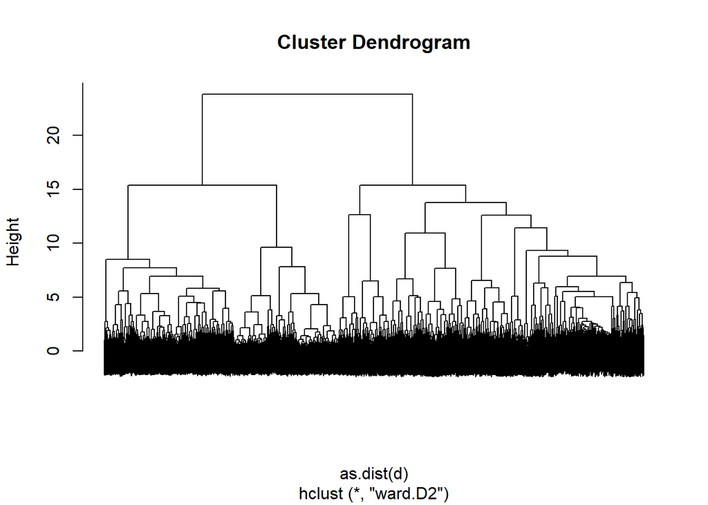

```r
#install.packages("matrixStats")
#install.packages("ggplot2")
library(matrixStats)
library(ggplot2)
xt = t(x) # transpose of data
sds = colSds(xt) # standard deviations of each rows and columns
#boxplot(sds)

# filtering variance > median variance across genes
xt_filter = xt[, sds > median(sds)]
#dim(xt_filter)

# Similarity measure: use absolute correlation between genes
cormat = cor(xt_filter)
#dim(d)

# distance
d = 1 - abs(cormat)

# Hierarchical clustering
#hclust_complete = hclust(as.dist(d), method = "complete")

#plot(hclust_complete, labels = FALSE)

hclust_ward = hclust(as.dist(d), method = "ward.D2")

dendro_plot = plot(hclust_ward, labels = FALSE)
```

```r
dendro_plot
```

**Explanation:** we first filtered out low-variance genes by removing those below the median standard deviation, retaining only the most variable features. We then computed a correlation matrix among these filtered genes, transformed it into a distance matrix (1 – absolute correlation), and performed hierarchical clustering using the Ward.D2 method. The resulting dendrogram provides a visual overview of the similarity structure among the remaining, high-variance genes.

```r
# Transpose the expression data
exprs_transposed <- t(exprs(drugdata))
pdata  = pData(drugdata)

# Combine the data#########
combined <- cbind(exprs_transposed, pdata)

tail(colnames(combined), 51)
```

```
##  [1] "title"                   "geo_accession"
##  [3] "status"                  "submission_date"
##  [5] "last_update_date"        "type"
##  [7] "channel_count"           "source_name_ch1"
##  [9] "organism_ch1"            "characteristics_ch1"
## [11] "characteristics_ch1.1"   "characteristics_ch1.2"
## [13] "characteristics_ch1.3"   "characteristics_ch1.4"
## [15] "characteristics_ch1.5"   "characteristics_ch1.6"
## [17] "characteristics_ch1.7"   "characteristics_ch1.8"
## [19] "characteristics_ch1.9"   "treatment_protocol_ch1"
## [21] "growth_protocol_ch1"     "molecule_ch1"
## [23] "extract_protocol_ch1"    "label_ch1"
## [25] "label_protocol_ch1"      "taxid_ch1"
## [27] "hyb_protocol"            "scan_protocol"
## [29] "description"             "data_processing"
## [31] "platform_id"             "contact_name"
## [33] "contact_email"           "contact_institute"
## [35] "contact_address"         "contact_city"
## [37] "contact_state"           "contact_zip/postal_code"
## [39] "contact_country"         "supplementary_file"
## [41] "data_row_count"          "compound:ch1"
## [43] "dose:ch1"                "hybridization date:ch1"
## [45] "rna extraction date:ch1" "route:ch1"
## [47] "Sex:ch1"                 "strain:ch1"
## [49] "time:ch1"                "tissue:ch1"
## [51] "vehicle:ch1"
```

```r
dim(pdata)
```

```
## [1] 2218   51
```

**Explanation:** we transposed the gene expression matrix so that each row represents a sample and each column represents a gene, then combined this transposed expression data with the corresponding phenotypic data. Finally, we inspected the column names to confirm that both the gene expression features and the phenotypic variables were successfully merged into the same dataset.

```r
library(dplyr)
# 1) Calculate expression means for controls (dose=0)
controls_mean = combined %>%
  filter(`dose:ch1` == "0 mg/kg") %>%
  group_by(`vehicle:ch1`,
           `time:ch1`,
           `tissue:ch1`,
           `route:ch1`,
           `Sex:ch1`,
           `hybridization date:ch1`,
           `strain:ch1`) %>%
  summarise(across(where(is.numeric), mean, na.rm = TRUE), .groups = "drop")
head(controls_mean)
```

```
## # A tibble: 6 × 31,106
##   `vehicle:ch1` `time:ch1` `tissue:ch1` `route:ch1` `Sex:ch1`
##   <chr>         <chr>      <chr>        <chr>       <chr>
## 1 CMC           0.25 d     Liver        Oral Gavage Male
## 2 CMC           0.25 d     Liver        Oral Gavage Male
## 3 CMC           0.25 d     Liver        Oral Gavage Male
## 4 CMC           1 d        Liver        Oral Gavage Male
## 5 CMC           1 d        Liver        Oral Gavage Male
## 6 CMC           1 d        Liver        Oral Gavage Male
## # ℹ 31,101 more variables: `hybridization date:ch1` <chr>, `strain:ch1` <chr>,
## #   `1367452_at` <dbl>, `1367453_at` <dbl>, `1367454_at` <dbl>,
## #   `1367455_at` <dbl>, `1367456_at` <dbl>, `1367457_at` <dbl>,
## #   `1367458_at` <dbl>, `1367459_at` <dbl>, `1367460_at` <dbl>,
## #   `1367461_at` <dbl>, `1367462_at` <dbl>, `1367463_at` <dbl>,
## #   `1367464_at` <dbl>, `1367465_at` <dbl>, `1367466_at` <dbl>,
## #   `1367467_at` <dbl>, `1367468_at` <dbl>, `1367469_at` <dbl>, …
```

```r
dim(controls_mean)
```

```
## [1]   188 31106
```

**Explanation:** we focused on the control samples (dose = 0 mg/kg) and grouped the data by key phenotypic variables (e.g., vehicle, time, tissue, route, sex, hybridization datte, and strain). We then calculated the mean of every numeric column within each group, effectively aggregating the average expression levels across the control samples. Finally, we inspected the first few rows (using head) and dimensions (using dim) of the resulting summarized dataset.

```r
# 2) For each compound, calculate mean expression according to levels of a-g above. Don’t separate according to dose level
library(data.table)
# Convert your data frame to a data.table
DT <- as.data.table(combined)

# Identify numeric columns (to apply the mean function only on these)
numeric_cols <- names(DT)[sapply(DT, is.numeric)]

# Filter and then group by + mean
compound_mean <- DT[
  `dose:ch1` != "0 mg/kg",
  lapply(.SD, mean, na.rm = TRUE),
  by = .(
    `compound:ch1`,
    `vehicle:ch1`,
    `time:ch1`,
    `tissue:ch1`,
    `route:ch1`,
    `Sex:ch1`,
    `hybridization date:ch1`,
    `strain:ch1`
  ),
  .SDcols = numeric_cols
]
dim(compound_mean)
```

```
## [1]  1389 31107
```

**Explanation:** To minimize the memory usage, I use the package of data.table here. we calculated the mean gene expression for each compound-treated sample without distinguishing by dose level. Using the data.table package, we filtered out control samples (dose = 0 mg/kg) and grouped the data by key phenotypic variables such as compound, vehicle, time, tissue, route, sex, hybridization date, and strain. We then computed the mean expression for all numeric gene expression columns within these groups. This summary provided an aggregated expression profile for each compound-treated condition, enabling comparisons across different treatments.

```r
# 3) Calculate difference in mean expression for controls and exposed that match in terms of a-g above
mean_diff <- controls_mean %>%
  inner_join(compound_mean, by = c("vehicle:ch1",
                                    "time:ch1",
                                    "tissue:ch1",
                                    "route:ch1",
                                    "Sex:ch1",
                                    "hybridization date:ch1",
                                    "strain:ch1"), suffix = c("_control", "_exposed")) %>%
  mutate(across(ends_with("_control"), ~ . - get(sub("_control", "_exposed", cur_column())), .names = "diff_{col}"))

head(mean_diff)
```

```
## # A tibble: 6 × 93,305
##   `vehicle:ch1` `time:ch1` `tissue:ch1` `route:ch1` `Sex:ch1`
##   <chr>         <chr>      <chr>        <chr>       <chr>
## 1 CMC           0.25 d     Liver        Oral Gavage Male
## 2 CMC           0.25 d     Liver        Oral Gavage Male
## 3 CMC           0.25 d     Liver        Oral Gavage Male
## 4 CMC           0.25 d     Liver        Oral Gavage Male
## 5 CMC           0.25 d     Liver        Oral Gavage Male
## 6 CMC           1 d        Liver        Oral Gavage Male
## # ℹ 93,300 more variables: `hybridization date:ch1` <chr>, `strain:ch1` <chr>,
## #   `1367452_at_control` <dbl>, `1367453_at_control` <dbl>,
## #   `1367454_at_control` <dbl>, `1367455_at_control` <dbl>,
## #   `1367456_at_control` <dbl>, `1367457_at_control` <dbl>,
## #   `1367458_at_control` <dbl>, `1367459_at_control` <dbl>,
## #   `1367460_at_control` <dbl>, `1367461_at_control` <dbl>,
## #   `1367462_at_control` <dbl>, `1367463_at_control` <dbl>, …
```

```r
dim(mean_diff)
```

```
## [1]   409 93305
```

**Explanation:** we calculated the difference in mean gene expression between control and exposed samples while ensuring they matched across key phenotypic variables (vehicle, time, tissue, route, sex, hybridization date, and strain). Using an inner join, we merged the pre-computed mean expression datasets for controls and exposed samples, aligning them based on these categorical variables. We then computed the expression difference for each gene by subtracting the exposed group mean from the corresponding control mean. This step allowed us to quantify gene expression changes associated with compound exposure while accounting for matched biological conditions.

```r
# 4) Calculate the mean difference in expression for each gene, averaged across compound.
# Doing the subtraction as matrix operations.

diff_cols <- mean_diff %>%
  select(starts_with("diff_"))

mean_diff_genes <- colMeans(as.matrix(diff_cols), na.rm = TRUE)
length(mean_diff_genes)
```

```
## [1] 31099
```

**Explanation:** I calculated the mean difference in gene expression for each gene by averaging across different compounds. First, I selected the columns containing expression differences (those starting with “diff_”). Then, I converted the selected data into a matrix and computed the column-wise mean while handling missing values. Finally, I determined the total number of genes analyzed.

```r
# filter out genes with variance less than the median variance value
library(dplyr)

# Compute variance for each gene (selecting only diff_ columns)
gene_var <- mean_diff %>%
  select(starts_with("diff_")) %>%
  summarise(across(everything(), var, na.rm = TRUE))

# Compute median variance
median_var <- median(unlist(gene_var), na.rm = TRUE)

# Select genes with variance above the median
high_var_genes <- names(gene_var)[unlist(gene_var) > median_var]

# Keep grouping columns + high-variance genes
grouping_cols <- c("compound:ch1", "vehicle:ch1", "time:ch1", "tissue:ch1",
                   "route:ch1", "Sex:ch1", "hybridization date:ch1", "strain:ch1")

filtered_mean_diff <- mean_diff %>%
  select(all_of(high_var_genes))

head(filtered_mean_diff)
```

```
## # A tibble: 6 × 15,549
##   diff_1367462_at_control diff_1367463_at_control diff_1367465_at_control
##                     <dbl>                   <dbl>                   <dbl>
## 1                   0.259                  -0.764                  0.317
## 2                   0.179                  -0.323                  0.0322
## 3                  -0.190                  -0.449                  0.215
## 4                   0.328                  -0.111                  0.0239
## 5                   0.458                  -0.303                 -0.247
## 6                   0.371                  -0.103                 -0.123
## # ℹ 15,546 more variables: diff_1367468_at_control <dbl>,
## #   diff_1367471_at_control <dbl>, diff_1367476_at_control <dbl>,
## #   diff_1367484_at_control <dbl>, diff_1367485_at_control <dbl>,
## #   diff_1367488_at_control <dbl>, diff_1367491_at_control <dbl>,
## #   diff_1367495_at_control <dbl>, diff_1367499_at_control <dbl>,
## #   diff_1367502_at_control <dbl>, diff_1367504_at_control <dbl>,
## #   diff_1367505_at_control <dbl>, diff_1367513_at_control <dbl>, …
```

```r
dim(filtered_mean_diff)
```

```
## [1]   409 15549
```

**Explanation:** we refined our analysis by filtering out genes with low variability in their expression differences. First, we computed the variance for each gene’s expression difference across matched control and exposed conditions. We then determined the median variance value and retained only genes with a variance above this threshold. This filtering step ensured that only the most variable genes were included in further analysis, reducing noise and focusing on genes with potentially meaningful differential expression patterns.

```r
# transpose the filtered_mean_diff
df_t <- t(filtered_mean_diff)
```

**Explanation:** we transpose the data we filtered above to restructured the data so that genes are now represented as rows and its expression values are represented as columns.

```r
# Use the Elbow Method in R to Find Optimal Clusters
library(cluster)
library(factoextra)
```

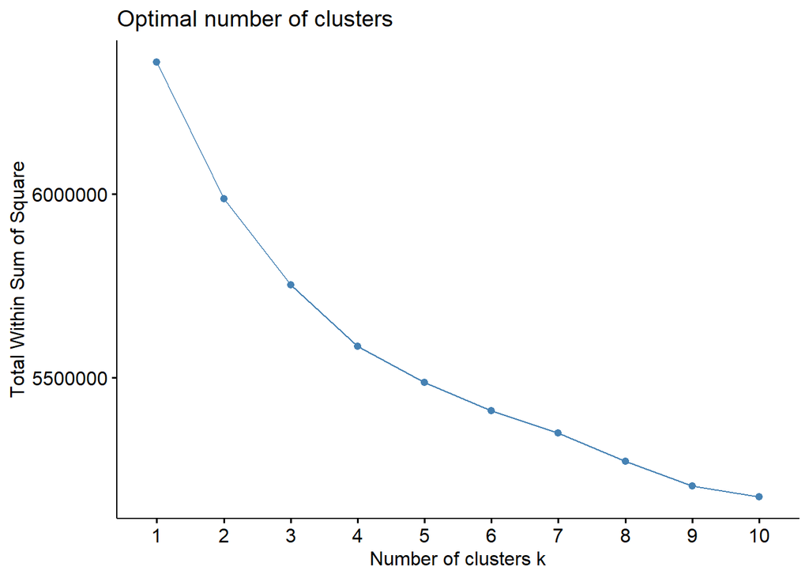

```r
cluster_data <- df_t

#remove rows with missing values
cluster_data <- na.omit(cluster_data)

#scale each variable to have a mean of 0 and sd of 1
cluster_data <- scale(cluster_data)

#create plot of number of clusters vs total within sum of squares
fviz_nbclust(cluster_data, kmeans, method = "wss")
```

**Explanation:**I used the Elbow Method to determine the optimal number of clusters for my dataset. First, I removed rows with missing values to ensure clean data. Then, I standardized the variables by scaling them to have a mean of 0 and a standard deviation of 1. Finally, I applied the Elbow Method using the within-cluster sum of squares (WSS) criterion and visualized the results with a plot.

In this plot it appears that there is an “elbow” or bend at k = 2 or 3 clusters. This is the point where the total within sum of squares begins to level off.

```r
# 5) Perform K means clustering of genes based on change in expression following exposure.

# Perform K-means clustering
set.seed(123)  # For reproducibility
k <- 3 # Optimal number of cluster
km <- kmeans(df_t, centers = k, nstart = 25)
```

**Explanation:** I performed K-means clustering to group genes based on changes in expression after exposure. First, I set a seed for reproducibility and specified three clusters as the optimal number based on the Elbow Method. Then, I applied the K-means algorithm to the dataset, initializing 25 random starts to ensure stable clustering results. The output includes cluster assignments for each gene.

K-means clustering with 3 clusters of sizes 3552, 4729, 7268

```
##
## === K-means cluster 1 ===
```

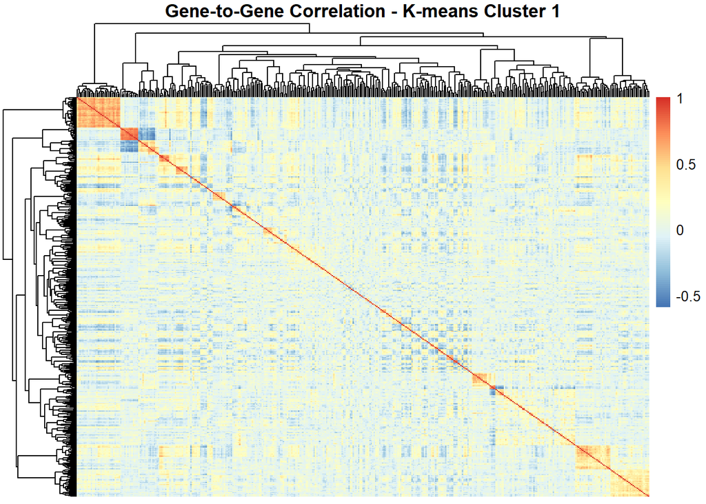

```
##
## === K-means cluster 2 ===
```

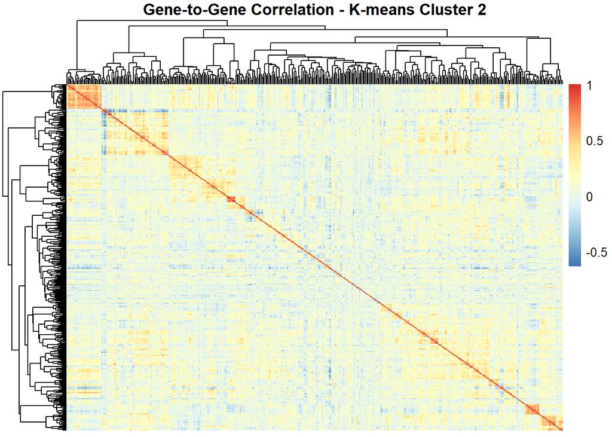

```
##
## === K-means cluster 3 ===
```

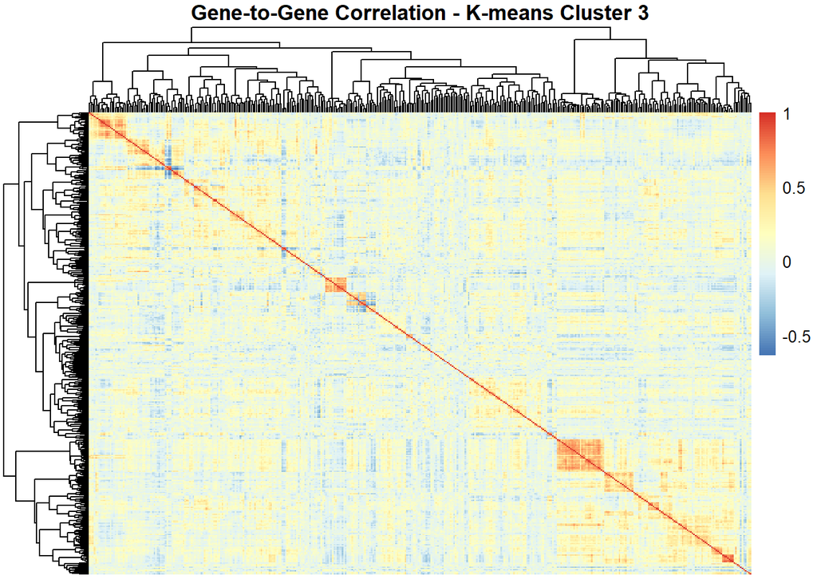

```r
library(pheatmap)
# use a for-loop to process clusters 1..k
for (c in seq_len(k)) {
  cat("\n=== K-means cluster", c, "===\n")

  # Genes in cluster c
  cluster_genes <- rownames(df_t)[km$cluster == c]

  # If the cluster has fewer than 2 genes, skip
  if (length(cluster_genes) < 2) {
    cat("Skipping cluster", c, "because it has < 2 genes.\n")
    next
  }

  # Subset the transposed matrix to these genes
  # rows = genes, columns = observations
  submat_t <- df_t[cluster_genes, , drop = FALSE]

  cor_mat <- cor(submat_t, method = "pearson", use = "pairwise.complete.obs")

  # 3.1b) Optionally convert correlation to distance
  dist_mat <- as.dist(1 - abs(cor_mat))

  # 3.1c) Hierarchical clustering on that distance
  hc <- hclust(dist_mat, method = "ward.D2")

  # 3.1d) Heatmap: The matrix to plot is the correlation matrix (genes x genes)
  pheatmap(
    cor_mat,
    cluster_rows = hc,
    cluster_cols = hc,
    # Alternatively,can let pheatmap do "distance = 1 - correlation" automatically,
    main = paste("Gene-to-Gene Correlation - K-means Cluster", c),
    show_rownames = FALSE, # set to TRUE if want to see gene labels
    show_colnames = FALSE
  )
}
```